# STSCI 4630 - Lec 03

Harry Lu

January 29, 2019

Population standardized skewness

$$\text{sk}=\text{E}\left[\left(\frac{x-\mu}{\sigma}\right)^3\right]=\frac{\text{E}\left[(x-\mu)^3\right]}{\sigma^3}$$

Population standardized kurtosis

$$\text{kur}=\text{E}\left[\left(\frac{x-\mu}{\sigma}\right)^4\right]=\frac{\text{E}\left[(x-\mu)^4\right]}{\sigma^4}$$

Normal distribution: $\text{sk}=0$ and $\text{kur}=3$

t distribution with degree of freedom $\text{df}$: $\text{sk}=0$ and $\text{kur}=3+\frac{6}{\text{df}-4}$

$$\hat{\text{sk}}=\frac{1}{n}\sum_{i=1}^{n}\left(\frac{x_i-\bar{x}}{s}\right)^3$$

$$\hat{\text{kur}}=\frac{1}{n}\sum_{i=1}^{n}\left(\frac{x_i-\bar{x}}{s}\right)^4$$

e.g. Dow Jones INDEX: $\hat{\text{sk}}\approx0$, $\hat{\text{kur}}\approx14$, so $14=3+\frac{6}{\text{df}-4}$, gives $\hat{\text{df}}\approx4.5$

Formal Test for Normality

$$\text{JB}=n\left[\frac{(\hat{\text{sk}})^2}{6}+\frac{(\hat{\text{kur}}-3)^2}{24}\right] \xrightarrow{d} \chi^2_2$$

Shapiro-Wilk test: based on the correlation between $X_{(i)}$ and $\text{E}(X_{(i)})$

$\text{E}(X_{(i)}) \leftrightarrow \Phi^{-1}\left(\frac{i}{n+1}\right),\Phi^{-1}\left(\frac{i-\frac{1}{2}}{n}\right)$

Checking for t-distributed Returns

Location-scale Student’s t-model: $y\sim a+bt_{(\text{df})}$, where $a$ is location parameter and $b$ is scale parameter

When $\text{df}=\infty$, $t_{(\infty)}=N(0,1)$, $y\sim N(a,b^2)$

When $\text{df}>1$, $y$ has mean $a$

When $\text{df}>2$, $y$ has standard deviation $b\cdot\sqrt{\frac{\text{df}}{\text{df}-2}}$

Let $F_{\text{df}}(t)$ be the cdf of $t_{(\text{df})}$

Compare $X_{(i)}$ with $F_{\text{df}}^{-1}\left(\frac{i}{n+1}\right)$, if the model holds $X_{(i)}\approx a+b\cdot F_{\text{df}}^{-1}\left(\frac{i}{n+1}\right)$

Get $\text{df}$ to use by $\hat{\text{df}}$ where $\left(\hat{a},\hat{b},\hat{\text{df}}\right)$ is the maximum likelihood estimate of $(a,b,\text{df})$

e.g. $n=3$, $\frac{i}{n+1}=0.25,0.50,0.75$ as $i=1,2,3$

- $X_{(1)}=\mu+\sigma\cdot\Phi^{-1}\left(\frac{1}{3+1}\right)=\mu+\sigma\cdot\Phi^{-1}(0.25)$
- $X_{(2)}=\mu+\sigma\cdot\Phi^{-1}\left(\frac{2}{3+1}\right)=\mu+\sigma\cdot\Phi^{-1}(0.50)=\mu$
- $X_{(3)}=\mu+\sigma\cdot\Phi^{-1}\left(\frac{3}{3+1}\right)=\mu+\sigma\cdot\Phi^{-1}(0.75)$

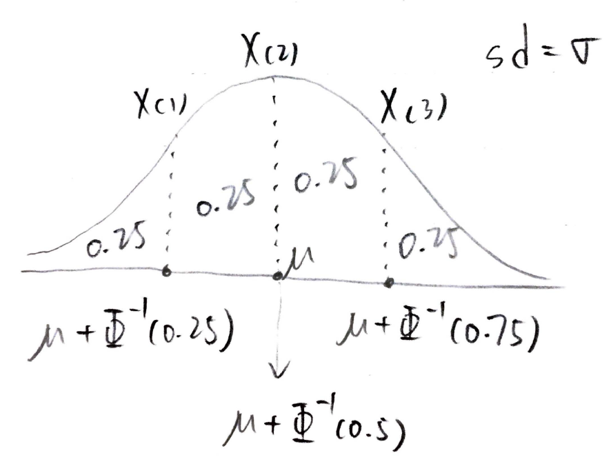

$X_{(i)}$ should be approximately the $\frac{i}{n+1}$ - quantile of the distribution. Or $\text{E}[y_{(i)}]\approx\mu+\sigma\cdot\Phi^{-1}\left(\frac{i-\frac{1}{2}}{n}\right)$

**Time Series Methods**

A time series is a collection of observed random variables indexed by time. A stochastic process is a model for a time series.

Discrete time series: $X_t$ is the variable at time $t$

- e.g. $X_1,X_2,X_3,\cdots$
- e.g. $X_0,X_1,X_2,\cdots$
- e.g. $X_{-2},X_{-1},X_0,X_1,X_2,\cdots$

Assume the time series is “systematic” to have a small collection of parameters to be estimated.

**(I) Strictly Stationary**

Assume $X_1,\cdots,X_n$ has the same distribution as $X_{1+k},\cdots,X_{n+k}$ for all $k$

e.g. $(X_2,X_7,X_{20})$ has the same distribution as $(X_{45},X_{50},X_{63})$. Also, $X_1$ and $X_2$ and $X_3$, etc. all have the same distribution

**(II) Weakly Stationary**

1. $\text{E}(X_t)=\mu$ for all $t$
   - e.g. $\text{E}(X_8)=\text{E}(X_{20})$
2. $\text{Var}(X_t)=\sigma^2$ for all $t$
   - e.g. $\text{Var}(X_8)=\text{Var}(X_{20})$
3. $\text{Cov}(X_t,X_u)=\gamma(|t-u|)$
   - e.g. $\text{Cov}(X_8)=\text{Cov}(X_{20})$

$\gamma(h)$ is called the auto-covariance function

$\gamma(0)=\text{Cov}(X_t,X_t)=\text{Var}(X_t)=\sigma^2$

The auto-correlation function $\rho(h)$ gives $\text{Corr}(X_t,X_u)=\rho(|t-u|)$

$$\rho(h)=\frac{\gamma(h)}{\sigma^2}=\frac{\gamma(h)}{\gamma(0)}$$

**Time Series Plot** (v.s. Time)

Weakly Stationary

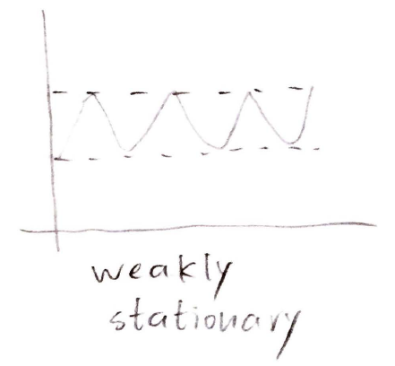

Increasing Mean

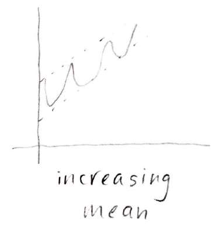

Increasing Variance

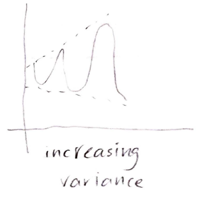

Strictly Stationary –> Weakly Stationary

Suppose $X_1,X_2,\cdots$ independent. $X_i\sim N(0,1)$, where $i$ is odder number. $X_j\sim \sqrt{\frac{\text{df}-2}{\text{df}}}\cdot t_{(\text{df})}$, where $j$ is even number ($\text{df}>2$).

**(III) Weak White Noise**

1. $\text{E}(X_t)=\mu$ for all $t$
2. $\text{Var}(X_t)=\sigma^2$ for all $t$
3. $\text{Cov}(X_t,X_u)=0$ for $t\neq u$

So $\gamma(0)=\sigma^2$, $\gamma(h)=0$ for $h\neq0$

and $\rho(0)=1$, $\rho(h)=0$ for $h\neq0$

Weak White Noise –> Weakly Stationary

**(IV) $i.i.d.$ White Noise**

Weak white noise where variables are $i.i.d.$

–> Strictly stationary

–> Weak White Noise

Thanks to *Zhenjie Shen* and *Wanxin Lyu* for help with the notes.